# Teaching R and Reproducibility in Norway

R

Reproducibility

Teaching

Data Science

AI/ML

Published

August 20, 2025

I had the privilege of traveling to Norway to assist my friend Brooke Wolford in teaching the inaugural Health AI in R workshop at NTNU last week. When she asked if I would be a guest instructor for her workshop I jumped at the opportunity! Brooke and I met in grad school while volunteering with our department’s Girls Who Code club, which Brooke co-founded. Back then, we spent many hours developing a custom curriculum for teaching high schoolers how to code for data science. It was great to be back in the saddle teaching with Brooke like old times! It is always a privilege to get to help other scientists gain computational skills, and I find that teaching through live coding helps freshen my own understanding as well.

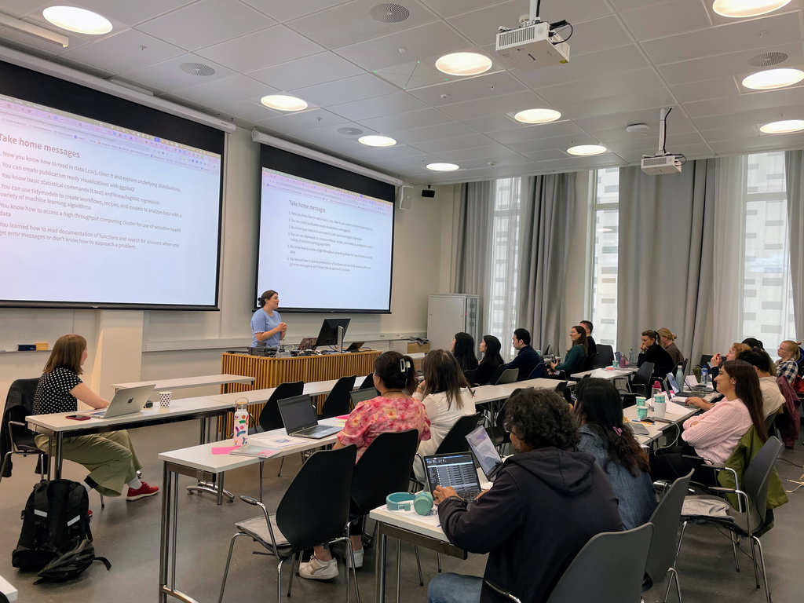

Brooke teaching at the conclusion of the workshop.

Over the course of this two-day workshop, graduate students and researchers from across Norway learned the basics of programming in R, data wrangling and visualization with the tidyverse, performing statistical tests, and training machine learning models. Brooke did a phenomenal job creating the workshop curriculum, which is [open and available on GitHub here](https://github.com/bnwolford/HealthAIinR). You can read Brooke’s workshop reflections in her LinkedIn post here.

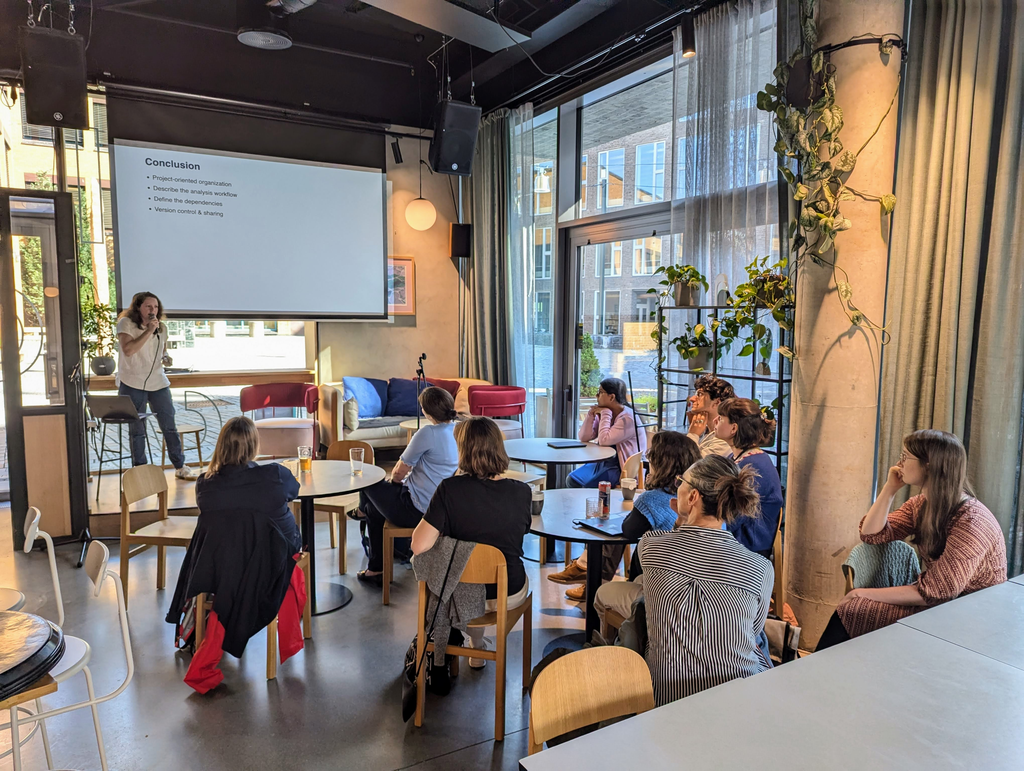

Speaking on reproducibility for R Ladies Trondheim.

[figure not shown]

Brooke and I at the R Ladies Trondheim meetup.

My spouse and I turned this trip into a longer vacation. We had a lovely time visiting Norway’s three largest cities, kayaking and hiking in Jostedalsbreen National Park, and taking in the breathtaking views of the fjords. Many thanks to my dear friend Brooke for extending the invitation, hosting us in Trondheim, and making this trip possible. I already can’t wait to come back!

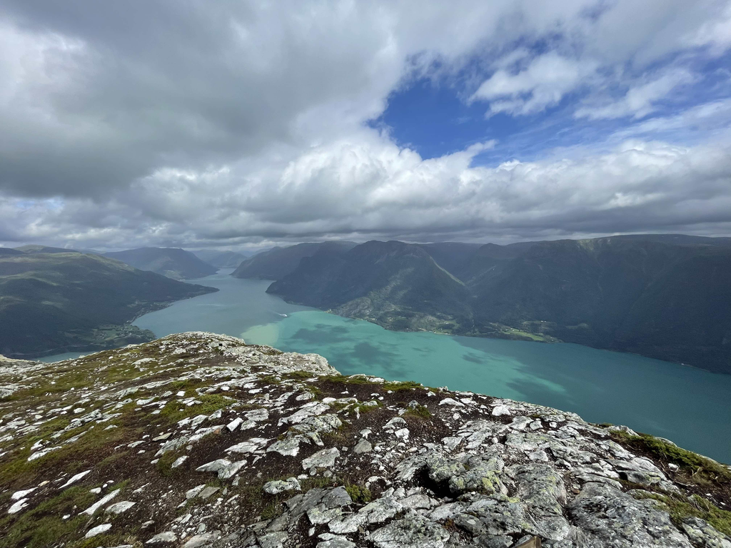

View of the Lustrafjord from Molden.